# IE48B - Final

Alihan Zer

24 01 2022

In this final, we are asked to predict the solar predictions for the given dataset.

```r
df <- read_csv("production_with_weather_data.csv")
df = data.table(df)

wmape <- function(actual, predicted){
  return(sum(abs(actual - predicted), na.rm=TRUE) / sum(abs(actual)))
}
```

After reading and converting into a data.table, some manipulations are needed. Specifically, the trend column should be added. Also, date column should be converted into more compact form, and day and month informations are required to be added.

```r
df[,trend:=1:.N]
df[,datetime:=ymd(date) + dhours(hour)]
df[,w_day:=as.character(wday(datetime))]
df[,mon:=as.character(month(datetime))]
```

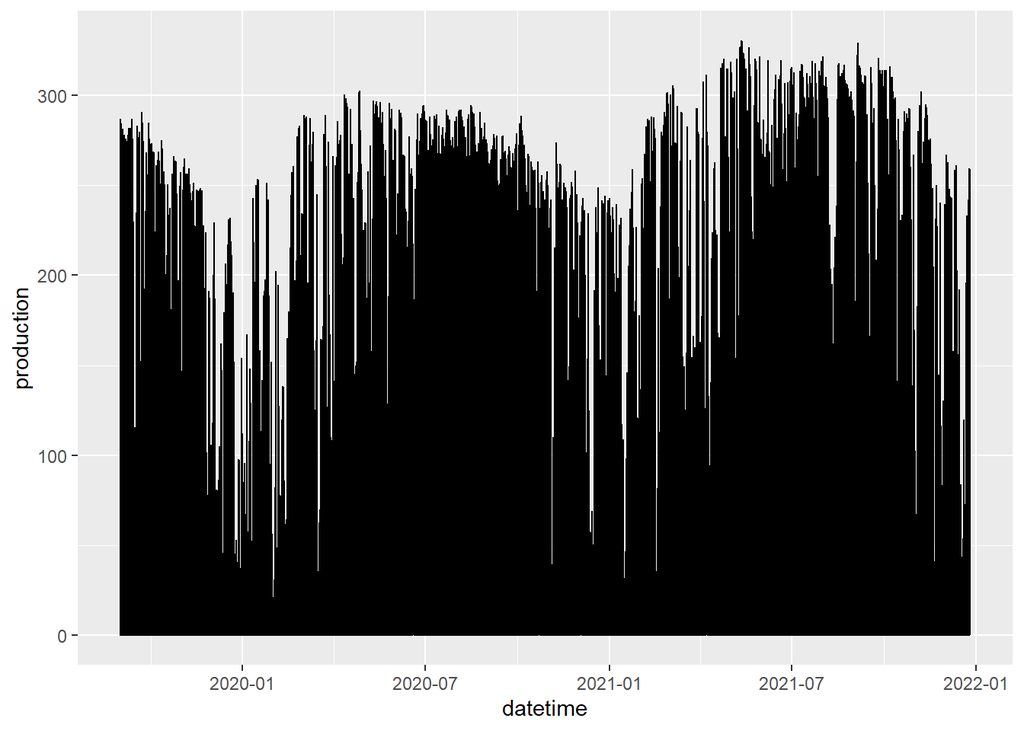

```r
ggplot(df, aes(x=datetime, y=production)) + geom_line()
```

Because there are many entries, this plot seems noisy. However, some comments still can be done. For instance, it can be seen that a drop is observed around january every year. Also, the production values are relatively higher around july.

Now, a model can be deployed with using only time variables.

```r
lm_base <- lm(production~trend+ w_day + mon + as.factor(hour), df)
summary(lm_base)
```

```
##
## Call:
## lm(formula = production ~ trend + w_day + mon + as.factor(hour),
##     data = df)
##
## Residuals:
##      Min       1Q   Median       3Q      Max
## -202.441  -20.046    1.221   28.172  108.915
##
## Coefficients:
##                     Estimate Std. Error t value Pr(>|t|)
## (Intercept)       -3.282e+01  1.896e+00 -17.308  < 2e-16 ***
## trend              4.562e-04  4.995e-05   9.132  < 2e-16 ***
## w_day2            -2.946e+00  1.064e+00  -2.769 0.005624 **
## w_day3            -1.465e+00  1.064e+00  -1.377 0.168554
## w_day4            -3.695e+00  1.064e+00  -3.472 0.000517 ***
## w_day5            -2.973e+00  1.067e+00  -2.787 0.005321 **
## w_day6            -4.217e+00  1.066e+00  -3.954 7.70e-05 ***
## w_day7            -3.497e+00  1.064e+00  -3.287 0.001015 **
## mon10              3.448e+01  1.364e+00  25.284  < 2e-16 ***
## mon11              1.573e+01  1.374e+00  11.450  < 2e-16 ***
## mon12             -1.613e+00  1.386e+00  -1.164 0.244525
## mon2               1.828e+01  1.519e+00  12.034  < 2e-16 ***
## mon3               2.129e+01  1.488e+00  14.305  < 2e-16 ***
## mon4               3.271e+01  1.502e+00  21.775  < 2e-16 ***
## mon5               5.011e+01  1.493e+00  33.556  < 2e-16 ***
## mon6               5.363e+01  1.510e+00  35.520  < 2e-16 ***
## mon7               6.074e+01  1.502e+00  40.439  < 2e-16 ***
## mon8               5.273e+01  1.508e+00  34.956  < 2e-16 ***
## mon9               4.410e+01  1.368e+00  32.240  < 2e-16 ***
## as.factor(hour)1  -1.566e-03  1.972e+00  -0.001 0.999367
## as.factor(hour)2  -2.005e-03  1.972e+00  -0.001 0.999189
## as.factor(hour)3   9.242e-04  1.972e+00   0.000 0.999626
## as.factor(hour)4   1.607e-02  1.972e+00   0.008 0.993499
## as.factor(hour)5   5.895e-01  1.972e+00   0.299 0.764975
## as.factor(hour)6   7.496e+00  1.972e+00   3.801 0.000144 ***
## as.factor(hour)7   3.803e+01  1.972e+00  19.287  < 2e-16 ***
## as.factor(hour)8   9.396e+01  1.972e+00  47.646  < 2e-16 ***
## as.factor(hour)9   1.521e+02  1.972e+00  77.122  < 2e-16 ***
## as.factor(hour)10  1.954e+02  1.972e+00  99.087  < 2e-16 ***
## as.factor(hour)11  2.182e+02  1.972e+00 110.663  < 2e-16 ***
## as.factor(hour)12  2.238e+02  1.972e+00 113.469  < 2e-16 ***
## as.factor(hour)13  2.133e+02  1.972e+00 108.175  < 2e-16 ***
## as.factor(hour)14  1.885e+02  1.972e+00  95.594  < 2e-16 ***
## as.factor(hour)15  1.460e+02  1.972e+00  74.052  < 2e-16 ***
## as.factor(hour)16  9.174e+01  1.972e+00  46.521  < 2e-16 ***
## as.factor(hour)17  4.021e+01  1.972e+00  20.389  < 2e-16 ***
## as.factor(hour)18  9.942e+00  1.972e+00   5.042 4.65e-07 ***
## as.factor(hour)19  1.013e+00  1.972e+00   0.514 0.607468
## as.factor(hour)20  5.405e-03  1.972e+00   0.003 0.997813
## as.factor(hour)21 -2.839e-03  1.972e+00  -0.001 0.998851
## as.factor(hour)22 -1.442e-02  1.972e+00  -0.007 0.994166
## as.factor(hour)23 -1.412e-02  1.972e+00  -0.007 0.994287
## ---
## Signif. codes:  0 '***' 0.001 '**' 0.01 '*' 0.05 '.' 0.1 ' ' 1
##
## Residual standard error: 40.53 on 20238 degrees of freedom
## Multiple R-squared:  0.8228, Adjusted R-squared:  0.8224
## F-statistic:  2292 on 41 and 20238 DF,  p-value: < 2.2e-16
```

As it can be seen hour = 0, mon = 1 and w_day = 1 are missing. This is because, these columns are linearly dependent with other columns. The significant values are denoted with ***.

The adjusted-R^2 0.8224. Now, let’s see if we can improve this value by adding other predictors.

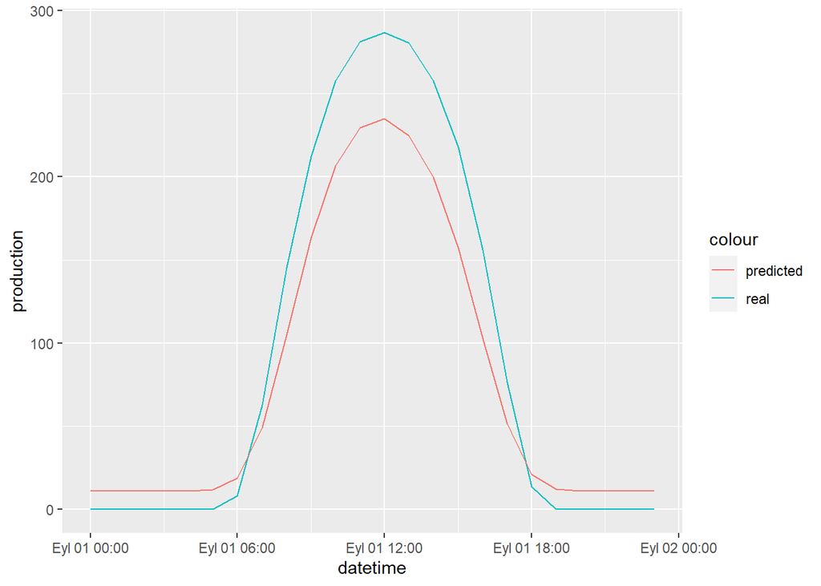

```r
df[, actual := production]
df[, predicted := predict(lm_base, df)]
ggplot(df[date=='2019-09-01'], aes(x=datetime)) + geom_line(aes(y = production, color = 'real'))+geom_line(aes(y=predicted, color = 'predicted'))
```

Now, the regression tree can be used to generate new features.

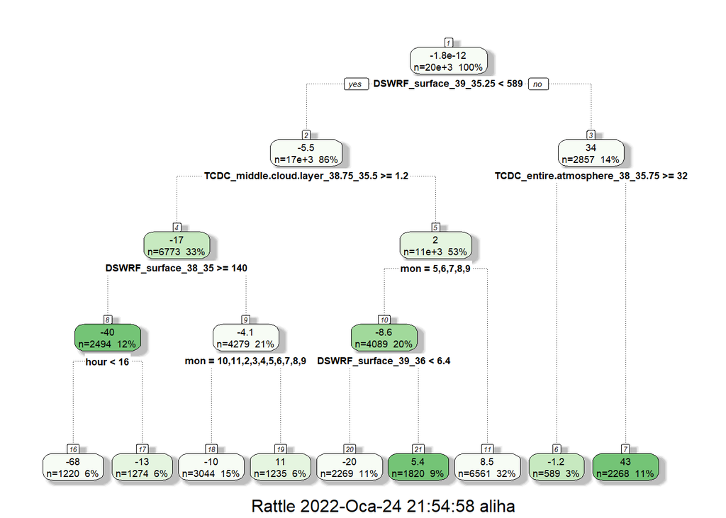

```r
df[,residual := actual - predicted]

fit_res_tree = rpart(residual~.-(date+actual+predicted+production),control = rpart.control(maxdepth = 4), data = df)
fancyRpartPlot(fit_res_tree)
```

This plot shows several important comparisons. For instance, the hour value being smaller than 16 affects the model. Also, the weather conditions (which can be derived with the month values) affects the model as well.

This tree can also be used to generate multiple constraints. With further analysis, it can be seen that the 7th box needs the most attention (i.e., it has the most total error.).

```r
df[, is_winter:= as.numeric(mon==12 | mon==1)]
df[, is_warm:= as.numeric((mon==5) | (mon==6) | (mon==7) | (mon==8) | (mon==9))]
df[, tcdc_const := TCDC_entire.atmosphere_38_35.75 >= 32]
df[, hour_ls := as.numeric((hour<16))]
df[, dswrf_const := DSWRF_surface_39_35.25 < 589]
```

With the new additions, a new model can be deployed.

```r
lm_base2 = lm(production ~ (trend + w_day + mon + as.factor(hour) + is_winter + is_warm + tcdc_const + hour_ls+ tcdc_const:dswrf_const), df)
summary(lm_base2)
```

```
##
## Call:
## lm(formula = production ~ (trend + w_day + mon + as.factor(hour) +
##     is_winter + is_warm + tcdc_const + hour_ls + tcdc_const:dswrf_const),
##     data = df)
##
## Residuals:
##      Min       1Q   Median       3Q      Max
## -191.007  -14.925    0.573   16.917  120.482
##
## Coefficients: (3 not defined because of singularities)
##                                   Estimate Std. Error t value Pr(>|t|)
## (Intercept)                      6.638e+01  1.976e+00  33.597  < 2e-16 ***
## trend                            4.539e-04  4.239e-05  10.708  < 2e-16 ***
## w_day2                          -2.529e+00  9.025e-01  -2.803 0.005073 **
## w_day3                          -1.112e+00  9.027e-01  -1.231 0.218203
## w_day4                          -2.747e+00  9.031e-01  -3.041 0.002357 **
## w_day5                          -2.315e+00  9.048e-01  -2.558 0.010535 *
## w_day6                          -2.888e+00  9.052e-01  -3.191 0.001421 **
## w_day7                          -3.099e+00  9.027e-01  -3.432 0.000599 ***
## mon10                            2.199e+01  1.176e+00  18.701  < 2e-16 ***
## mon11                            1.121e+01  1.173e+00   9.558  < 2e-16 ***
## mon12                           -2.979e+00  1.177e+00  -2.531 0.011367 *
## mon2                             1.541e+01  1.289e+00  11.961  < 2e-16 ***
## mon3                             1.473e+01  1.266e+00  11.637  < 2e-16 ***
## mon4                             2.177e+01  1.294e+00  16.828  < 2e-16 ***
## mon5                             2.687e+01  1.303e+00  20.629  < 2e-16 ***
## mon6                             2.604e+01  1.326e+00  19.638  < 2e-16 ***
## mon7                             2.239e+01  1.353e+00  16.553  < 2e-16 ***
## mon8                             2.025e+01  1.338e+00  15.140  < 2e-16 ***
## mon9                             1.878e+01  1.210e+00  15.521  < 2e-16 ***
## as.factor(hour)1                 1.538e-01  1.672e+00   0.092 0.926746
## as.factor(hour)2                 2.199e-01  1.672e+00   0.131 0.895395
## as.factor(hour)3                 3.559e-01  1.672e+00   0.213 0.831455
## as.factor(hour)4                -4.942e-01  1.672e+00  -0.296 0.767588
## as.factor(hour)5                 2.124e-01  1.672e+00   0.127 0.898959
## as.factor(hour)6                 7.118e+00  1.672e+00   4.257 2.09e-05 ***
## as.factor(hour)7                 3.757e+01  1.672e+00  22.463  < 2e-16 ***
## as.factor(hour)8                 9.360e+01  1.672e+00  55.970  < 2e-16 ***
## as.factor(hour)9                 1.520e+02  1.672e+00  90.875  < 2e-16 ***
```

[output cut: 12 more lines]

```
## as.factor(hour)22               -2.141e-01  1.672e+00  -0.128 0.898148
## as.factor(hour)23               -1.407e-02  1.672e+00  -0.008 0.993288
## is_winter                               NA         NA      NA       NA
## is_warm                                 NA         NA      NA       NA
## tcdc_constTRUE                  -5.020e+01  1.630e+00 -30.792  < 2e-16 ***
## hour_ls                                 NA         NA      NA       NA
## tcdc_constFALSE:dswrf_constTRUE -7.694e+01  1.033e+00 -74.469  < 2e-16 ***
## tcdc_constTRUE:dswrf_constTRUE  -4.549e+01  1.621e+00 -28.065  < 2e-16 ***
## ---
## Signif. codes:  0 '***' 0.001 '**' 0.01 '*' 0.05 '.' 0.1 ' ' 1
##
## Residual standard error: 34.37 on 20231 degrees of freedom
##   (4 observations deleted due to missingness)
## Multiple R-squared:  0.8726, Adjusted R-squared:  0.8723
## F-statistic:  3148 on 44 and 20231 DF,  p-value: < 2.2e-16
```

As it can be seen, adjusted R^2 values has increased significantly.

```r
df[,predicted := predict(lm_base2, df)]
df[order(datetime, decreasing = T), .(predicted, production, datetime)]
```

```
##        predicted production            datetime
##     1: -7.447074          0 2021-12-25 23:00:00
##     2: -7.647522          0 2021-12-25 22:00:00
##     3: -6.149795          0 2021-12-25 21:00:00
##     4: -6.097631          0 2021-12-25 20:00:00
##     5: -5.184703          0 2021-12-25 19:00:00
##    ---
## 20276:  7.729780          0 2019-09-01 04:00:00
## 20277:  8.579516          0 2019-09-01 03:00:00
## 20278:  8.443003          0 2019-09-01 02:00:00
## 20279:  8.376421          0 2019-09-01 01:00:00
## 20280:  8.222214          0 2019-09-01 00:00:00
```

```r
df[date<'2021-12-25' & date>'2021-11-01', .(predicted, datetime)]
```

```
##        predicted            datetime
##    1: -10.583254 2021-11-02 00:00:00
##    2: -10.429047 2021-11-02 01:00:00
##    3: -10.362465 2021-11-02 02:00:00
##    4: -10.225952 2021-11-02 03:00:00
##    5: -11.075688 2021-11-02 04:00:00
##   ---
## 1244:  -4.985166 2021-12-24 19:00:00
## 1245:  -5.898094 2021-12-24 20:00:00
## 1246:  -5.950258 2021-12-24 21:00:00
## 1247:  -7.447985 2021-12-24 22:00:00
## 1248:  -7.247537 2021-12-24 23:00:00
```

The model predicted negative production values for early hour values. This shows that the model can be improved by solving this issue. Unfortunately, due to time issues of the final exam I am going to apply an easier (yet debatable) method. We can convert negative production values into 0’s, since it is impossible to produce negative quantity.

```r
preds = df[date<'2021-12-25' & date>'2021-11-01', .(predicted, datetime)]

preds[predicted<0, predicted:=0]
preds
```

```
##       predicted            datetime
##    1:         0 2021-11-02 00:00:00
##    2:         0 2021-11-02 01:00:00
##    3:         0 2021-11-02 02:00:00
##    4:         0 2021-11-02 03:00:00
##    5:         0 2021-11-02 04:00:00
##   ---
## 1244:         0 2021-12-24 19:00:00
## 1245:         0 2021-12-24 20:00:00
## 1246:         0 2021-12-24 21:00:00
## 1247:         0 2021-12-24 22:00:00
## 1248:         0 2021-12-24 23:00:00
```

After this manipulation, we are asked to compare these predictions with two days before.

```r
act = df[date<'2021-12-23' & date>'2021-10-30', .(production, datetime)]
act
```

```
##       production            datetime
##    1:          0 2021-10-31 00:00:00
##    2:          0 2021-10-31 01:00:00
##    3:          0 2021-10-31 02:00:00
##    4:          0 2021-10-31 03:00:00
##    5:          0 2021-10-31 04:00:00
##   ---
## 1244:          0 2021-12-22 19:00:00
## 1245:          0 2021-12-22 20:00:00
## 1246:          0 2021-12-22 21:00:00
## 1247:          0 2021-12-22 22:00:00
## 1248:          0 2021-12-22 23:00:00
```

```r
comps = matrix(c(act$production, preds$predicted), ncol = 2)
comps = data.frame(comps)
colnames(comps) = c("Actual", "Predicted")
head(comps, 50)
```

```
##         Actual  Predicted
## 1    0.0000000   0.000000
## 2    0.0000000   0.000000
## 3    0.0000000   0.000000
## 4    0.0000000   0.000000
## 5    0.0000000   0.000000
## 6    0.0000000   0.000000
## 7    0.3961627   0.000000
## 8    8.0418970  26.986618
## 9   41.1381244  83.022319
## 10  80.0256938 141.391847
## 11 121.6011373 161.350460
## 12 149.3731162 178.564206
## 13 169.7722393 179.956856
## 14 121.0924886 166.843164
```

[output cut: 36 more lines]

```r
wmape(comps$Actual, comps$Predicted)
```

```
## [1] 0.5689755
```

The wMAPE value is 0.5689755